# CAR Dashboard — Préparation Menace MVE

[figure not shown]

République Centrafricaine

# Préparation de la RCA face à la menace d’importation de la MVE

Maladie à Virus Ebola — souche Bundibugyo — export HTML généré le 25/06/2026 à 03:25

## Vue d’ensemble

Voyageurs dépistés

9 537

15 PoE suivis

Alertes PoE

49

Validées : 0

Districts prioritaires

Préparation ciblée

Activités préparatoires

113

Avancement moyen : 0 %

Formations

2

Réalisées : 0

Laboratoires prévus

2

Gap matériel : 230

Cas confirmés RDC/Ouganda

1 068

CFR : 25,2 %

Score indicatif préparation

0 %

Activités, formations et laboratoires

[figure not shown]

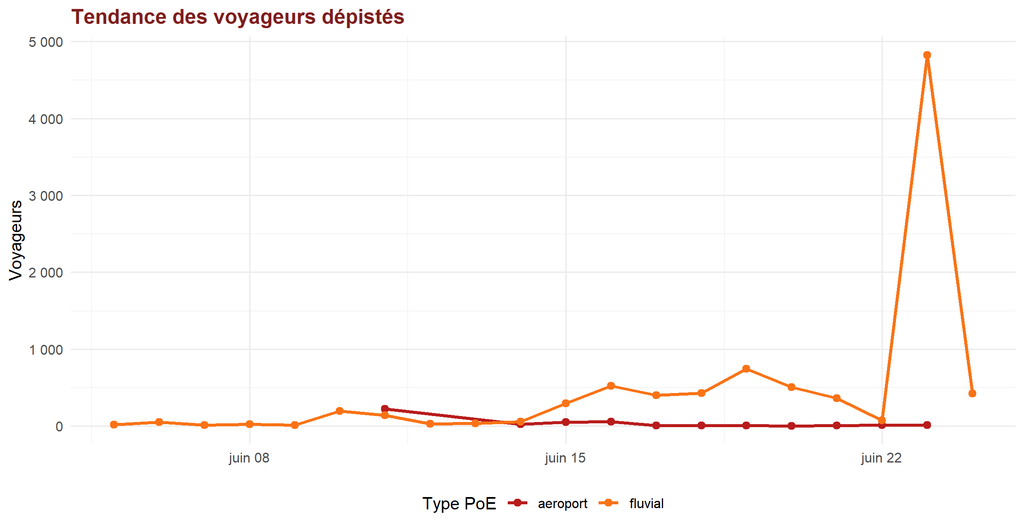

## Contexte de la menace MVE

Le Ministère de la Santé de la République Démocratique du Congo a déclaré le 15 mai 2026 la 17ème épidémie de la maladie à virus Ebola. En effet, les analyses de laboratoire réalisées par l’Institut National de Recherche Biomédicale (INRB) en date du 14 mai 2026 sur 13 échantillons sanguins prélevés ont confirmé 8 cas positifs de maladie à virus Ebola, souche Bundibugyo. Le cas index supposé de la maladie serait un infirmier décédé, d’âge inconnu au Centre Médical Evangélique (CME) de Bunia. Le cas remonte au 24 avril 2026 dans la zone de santé de Rwampara. Cet infirmier avait présenté une symptomatologie évocatrice de la maladie à virus Ebola : fièvre, hémorragies et des vomissements et une fatigue intense. A la date du 15 mai 2026, le nombre total de cas suspects notifiés est de 246 et 80 décès parmi lesquels 4 ont été testés positifs soit une létalité de 32,5%. Le même jour, un peu plus tard dans la soirée, l’Ouganda déclare à son tour l’épidémie de la maladie à virus Ebola. Le cas est un sujet de nationalité Congolaise, âgé de 59 ans et admit à l’hôpital de Kibuli le 11 mai 2026. Il présentait une détresse respiratoire, des épisodes de fièvre, douleurs épigastriques, nausée, fièvre avec des difficultés à uriner. Après son admission, son état s’est rapidement détérioré à la suite de saignements et il est décédé le 14 mai 2026 en soins intensifs. Les résultats de l’échantillon sanguin prélevé et acheminé au laboratoire du Central Emergency Surveillance and Response Support de Wandegeya en Ouganda ont confirmé la maladie à virus Ebola souche Bundibugyo. L’OMS a déclaré le 16 mai 2026 cette épidémie comme Urgence de Santé Publique de Porté Internationale (USPPI). Le 18 mai, sur recommandation du groupe consultatif d’urgence, l’Africa CDC a déclaré cette épidémie comme Urgence de Santé Publique de Sécurité Continentale (USPSC).

## Chronologie des activités préparatoires

| id_activite | date_activite | titre_activite | description | pilier | district | localite | responsable | partenaire | statut | resultat_cle | commentaire | source_donnees | source_type |
| --- | --- | --- | --- | --- | --- | --- | --- | --- | --- | --- | --- | --- | --- |
| CHR_001 | 2026-06-20 | Réunion de coordination MVE | Activation du suivi multisectoriel. | Coordination | National | Bangui | À renseigner | À renseigner | réalisée | Compte rendu disponible | Donnée fictive | templates_donnees_dashboard_MVE.xlsx | Données réelles importées |
| CHR_002 | 2026-06-25 | Briefing PoE | Renforcement des circuits d’alerte. | Surveillance épidémiologique | Bimbo | M’Poko | À renseigner | À renseigner | planifiée | À renseigner | Donnée fictive | templates_donnees_dashboard_MVE.xlsx | Données réelles importées |

## Surveillance aux points d’entrée fluviaux

Voyageurs contrôlés

9 134

127 rapports reçus

Signaux T° ≥ 38 °C

44

Taux : 0,5 %

Alertes vérifiées

44

Vérification : 100 %

Alertes validées

0

Validation : 0 %

PoE fluviaux observés

14

4 districts

### Lecture épidémiologique et opérationnelle

- **9 134 voyageurs** ont été contrôlés sur 20 jour(s), à partir de 127 rapport(s) reçu(s), du 05 juin 2026 au 24 juin 2026 .
- Le pic journalier est de **4 825** voyageurs le 23 juin 2026 .
- Le PoE **BEACH** concentre 22,3 % du volume contrôlé ( 2 040 voyageurs).
- **44 température(s) ≥ 38 °C** ont été enregistrées, soit 0,5 % des voyageurs contrôlés.
- 44 alerte(s)/signal(aux) de dépistage ont été détecté(s), 44 vérifié(s), et 0 validé(s). Aucune alerte n’est enregistrée comme validée dans le fichier.

#### Activité et tendances

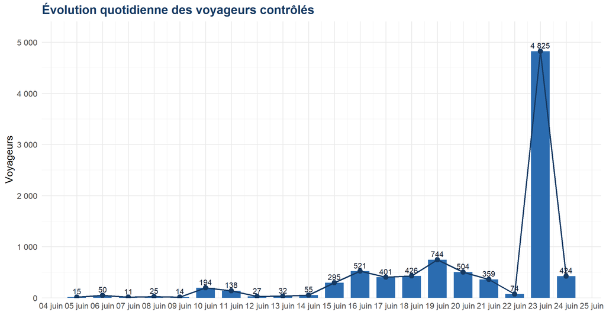

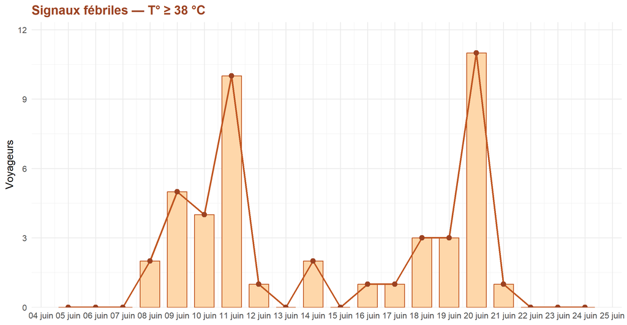

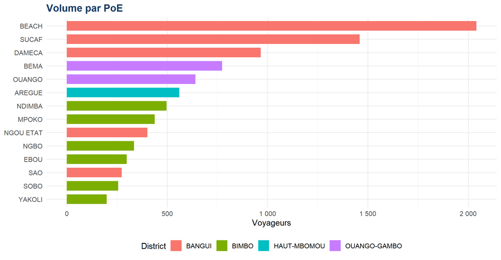

#### Alertes et priorités

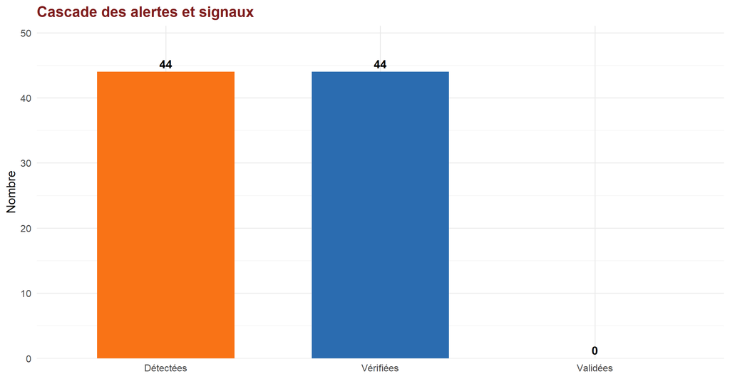

| district_sanitaire | point_entree | voyageurs | temp_sup38 | alertes_detectees | alertes_verifiees | alertes_validees | taux_fievre |
| --- | --- | --- | --- | --- | --- | --- | --- |
| OUANGO-GAMBO | BEMA | 774 | 25 | 25 | 25 | 0 | 0.0322997416020672 |
| OUANGO-GAMBO | OUANGO | 640 | 17 | 17 | 17 | 0 | 0.0265625 |
| BIMBO | MPOKO | 438 | 2 | 2 | 2 | 0 | 0.0045662100456621 |

#### Tableau détaillé des PoE

[output not shown]

[output cut: 4 more lines]

#### Conclusions et actions prioritaires

### Conclusions et actions prioritaires proposées

1. Investiguer et documenter toutes les alertes/signaux : définition de cas, symptômes, exposition, itinéraire, vérification et issue finale.
2. Afficher et briefer les procédures opérationnelles MVE dans chaque PoE : détection, vérification, validation, isolement temporaire et référence.
3. Formaliser le référentiel des PoE attendus : district, type de PoE, jours d’activité, fréquence de rapportage et responsable de notification.
4. Renforcer les PoE à forte charge ou avec signaux fébriles : agents, thermomètres fonctionnels, EPI, espace d’isolement temporaire et circuit de référence.
5. Ajouter les variables MVE critiques : provenance, destination, voyage en zone affectée dans les 21 jours, symptômes, exposition, délai de vérification, isolement et référence.

## Surveillance à l’Aéroport international Bangui M’Poko

Voyageurs aéroport

403

Température ≥ 38°C

5

1,2 %

Alertes détectées

5

Alertes validées

0

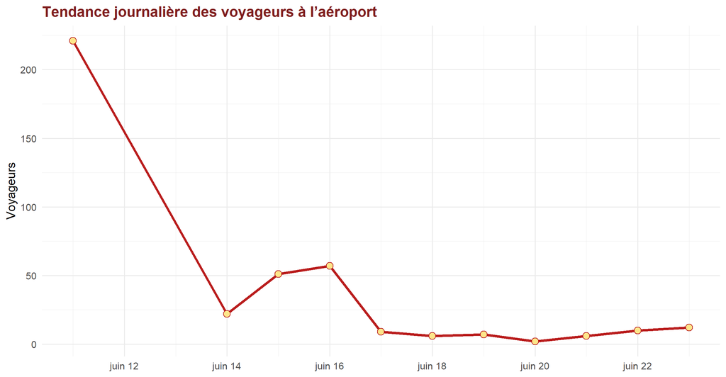

## Matrice des formations et chronogramme

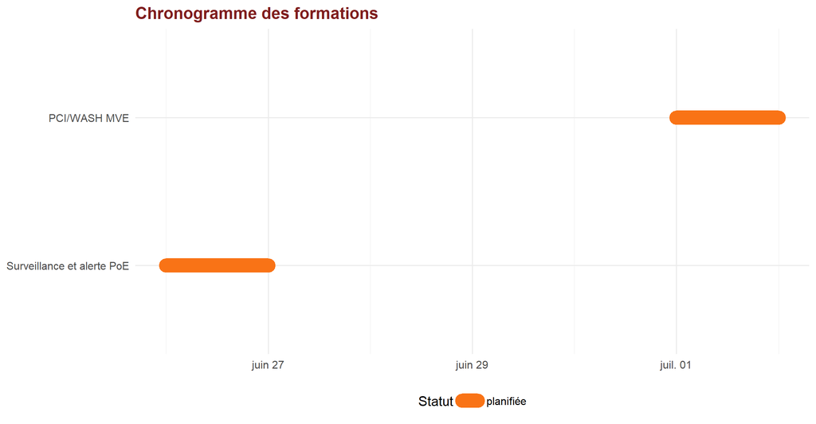

| id_formation | intitule_formation | pilier | cible | district | localite | date_debut_prevue | date_fin_prevue | date_debut_reelle | date_fin_reelle | participants_attendus | participants_formes | responsable | partenaire | statut | observations | source_donnees | source_type |
| --- | --- | --- | --- | --- | --- | --- | --- | --- | --- | --- | --- | --- | --- | --- | --- | --- | --- |
| FOR_001 | Surveillance et alerte PoE | Surveillance épidémiologique | Agents PoE | Bimbo | M’Poko | 2026-06-26 | 2026-06-27 | NA | NA | 30 | 0 | À renseigner | À renseigner | planifiée | Donnée fictive | templates_donnees_dashboard_MVE.xlsx | Données réelles importées |
| FOR_002 | PCI/WASH MVE | PCI/WASH et EDS | FOSA prioritaires | Bangassou | Bangassou | 2026-07-01 | 2026-07-02 | NA | NA | 25 | 0 | À renseigner | À renseigner | planifiée | Donnée fictive | templates_donnees_dashboard_MVE.xlsx | Données réelles importées |

## Piliers de préparation et réponse

[output not shown]

## Activités par pilier

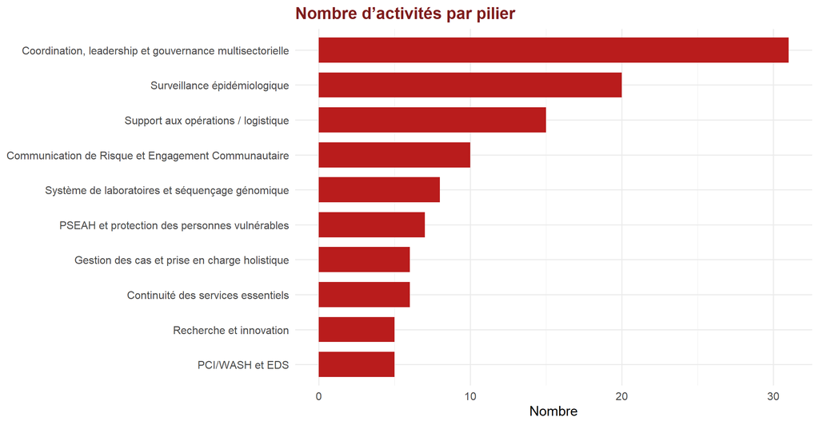

| id_activite | pilier | domaine_intervention | activite | sous_activite | indicateur | cible | valeur_realisee | unite | taux_avancement | district | localite | responsable | partenaire | date_debut | date_fin | statut | niveau_priorite | goulot_etranglement | action_correctrice | cout_total | cout_investissement | cout_operationnel | commentaire | source_donnees | source_type |
| --- | --- | --- | --- | --- | --- | --- | --- | --- | --- | --- | --- | --- | --- | --- | --- | --- | --- | --- | --- | --- | --- | --- | --- | --- | --- |
| communication_de_r_1 | Communication de Risque et Engagement Communautaire | NA | Réunion Engagement Communautaire Bangui (Remboursement de transport des acteurs) | NA | NA | NA | NA | NA | 0 | National | NA | NA | NA | NA | NA | planifiée | moyenne | NA | NA | 21000000 | 0 | 21000000 | Importé depuis un fichier de pilier existant | Communication de Risque et Engagement communautaire.xlsx | Données réelles importées |
| communication_de_r_2 | Communication de Risque et Engagement Communautaire | NA | Réunion Engagement Communautaire dans les autres districts à risque (Remboursement de transport pour les acteurs des districts) | NA | NA | NA | NA | NA | 0 | National | NA | NA | NA | NA | NA | planifiée | moyenne | NA | NA | 120000000 | NA | 120000000 | Importé depuis un fichier de pilier existant | Communication de Risque et Engagement communautaire.xlsx | Données réelles importées |
| communication_de_r_3 | Communication de Risque et Engagement Communautaire | NA | Production des matériels de communication, Communication de masse, documentaires, artistes, évidences) | NA | NA | NA | NA | NA | 0 | National | NA | NA | NA | NA | NA | planifiée | moyenne | NA | NA | 500000000 | 500000000 | NA | Importé depuis un fichier de pilier existant | Communication de Risque et Engagement communautaire.xlsx | Données réelles importées |
| communication_de_r_4 | Communication de Risque et Engagement Communautaire | NA | Coordination et suivi evaluation | NA | NA | NA | NA | NA | 0 | National | NA | NA | NA | NA | NA | planifiée | moyenne | NA | NA | 0 | NA | 0 | Importé depuis un fichier de pilier existant | Communication de Risque et Engagement communautaire.xlsx | Données réelles importées |
| communication_de_r_5 | Communication de Risque et Engagement Communautaire | NA | Réunion de coordination et d'analyse des feedbacks communautaires (pause café, remboursement de carburant des membres CREC | NA | NA | NA | NA | NA | 0 | National | NA | NA | NA | NA | NA | planifiée | moyenne | NA | NA | 8000000 | NA | 8000000 | Importé depuis un fichier de pilier existant | Communication de Risque et Engagement communautaire.xlsx | Données réelles importées |
| communication_de_r_6 | Communication de Risque et Engagement Communautaire | NA | Organisation des missions de supervision des activités de sensibilisation | NA | NA | NA | NA | NA | 0 | National | NA | NA | NA | NA | NA | planifiée | moyenne | NA | NA | 14400000 | NA | 14400000 | Importé depuis un fichier de pilier existant | Communication de Risque et Engagement communautaire.xlsx | Données réelles importées |
| communication_de_r_7 | Communication de Risque et Engagement Communautaire | NA | Location véhicule | NA | NA | NA | NA | NA | 0 | National | NA | NA | NA | NA | NA | planifiée | moyenne | NA | NA | 2800000 | NA | 2800000 | Importé depuis un fichier de pilier existant | Communication de Risque et Engagement communautaire.xlsx | Données réelles importées |
| communication_de_r_8 | Communication de Risque et Engagement Communautaire | NA | Carburant | NA | NA | NA | NA | NA | 0 | National | NA | NA | NA | NA | NA | planifiée | moyenne | NA | NA | 10000000 | NA | 10000000 | Importé depuis un fichier de pilier existant | Communication de Risque et Engagement communautaire.xlsx | Données réelles importées |
| communication_de_r_9 | Communication de Risque et Engagement Communautaire | NA | Renforcement des capacités des acteurs communautaires (remboursement de transport et collation) | NA | NA | NA | NA | NA | 0 | National | NA | NA | NA | NA | NA | planifiée | moyenne | NA | NA | 50000000 | NA | 50000000 | Importé depuis un fichier de pilier existant | Communication de Risque et Engagement communautaire.xlsx | Données réelles importées |
| communication_de_r_10 | Communication de Risque et Engagement Communautaire | NA | TOTAL | NA | NA | NA | NA | NA | 0 | National | NA | NA | NA | NA | NA | planifiée | moyenne | NA | NA | 726200000 | 500000000 | 226200000 | Importé depuis un fichier de pilier existant | Communication de Risque et Engagement communautaire.xlsx | Données réelles importées |

[output cut: 103 more lines]

## Laboratoires, équipements et sites d’installation

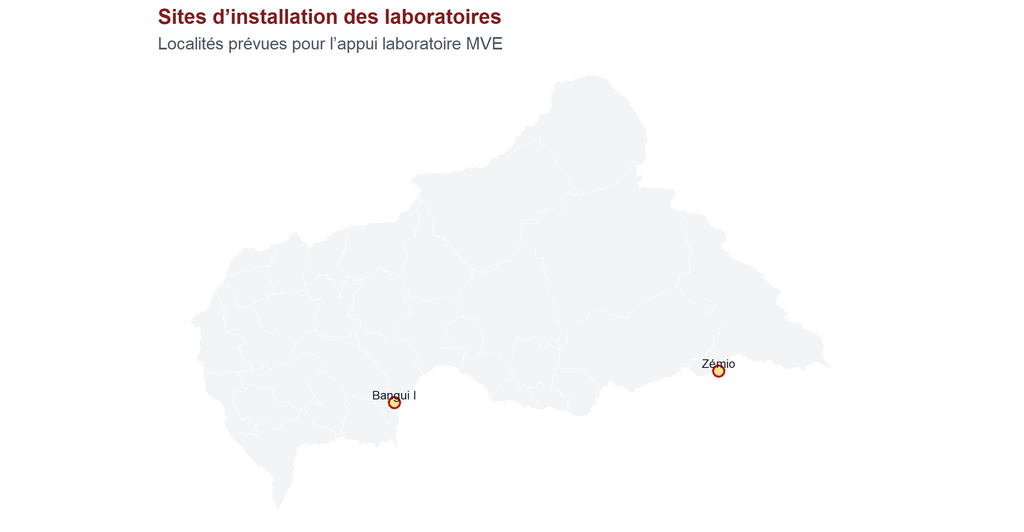

| id_materiel | nom_materiel | categorie | description | quantite_disponible | quantite_requise | gap | priorite | localisation_prevue | statut_acquisition | image_materiel | commentaire | source_donnees | source_type |
| --- | --- | --- | --- | --- | --- | --- | --- | --- | --- | --- | --- | --- | --- |
| MAT_001 | EPI complet | PCI | Kit de protection individuelle | 120 | 300 | 180 | haute | Districts prioritaires | en cours | NA | Donnée fictive | templates_donnees_dashboard_MVE.xlsx | Données réelles importées |
| MAT_002 | Triple emballage échantillons | Laboratoire | Transport sécurisé des échantillons | 30 | 80 | 50 | haute | Sites laboratoires | planifiée | NA | Donnée fictive | templates_donnees_dashboard_MVE.xlsx | Données réelles importées |

## Cartes stratégiques

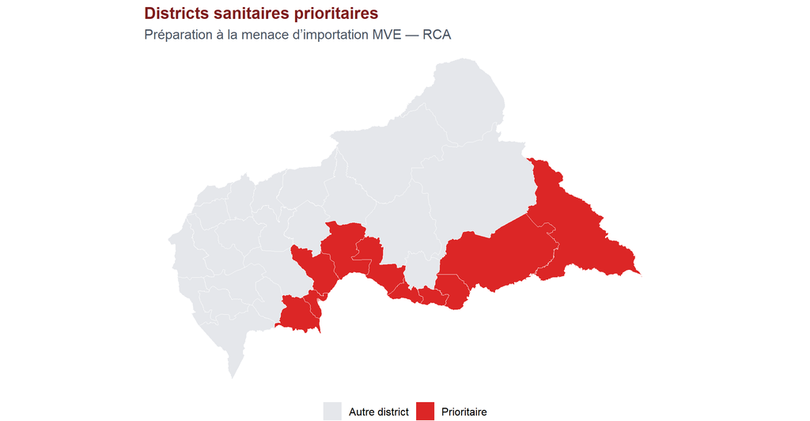

| id_site | localite | district_sanitaire | region_sanitaire | latitude | longitude | type_laboratoire | niveau_laboratoire | statut_installation | date_prevue_installation | partenaire_appui | commentaire | source_donnees | source_type |
| --- | --- | --- | --- | --- | --- | --- | --- | --- | --- | --- | --- | --- | --- |
| LAB_001 | Zémio | Haut-Mbomou | RS6 | 5.032 | 25.136 | Laboratoire d’appui MVE | Site périphérique | planifiée | 2026-07-05 | À renseigner | Donnée fictive | templates_donnees_dashboard_MVE.xlsx | Données réelles importées |
| LAB_002 | Bangui I | Bangui I | RS7 | 4.394 | 18.558 | Laboratoire d’appui MVE | Référence nationale | planifiée | 2026-07-05 | À renseigner | Donnée fictive | templates_donnees_dashboard_MVE.xlsx | Données réelles importées |

## Situation épidémiologique RDC et Ouganda

Cas confirmés cumulés

1 068

RDC + Ouganda

CFR confirmé

25,2 %

Cas confirmés dernières 24h

45

RDC — dernière date du fichier

Décès confirmés

269

Guérisons

126

Cas confirmés Ouganda

20

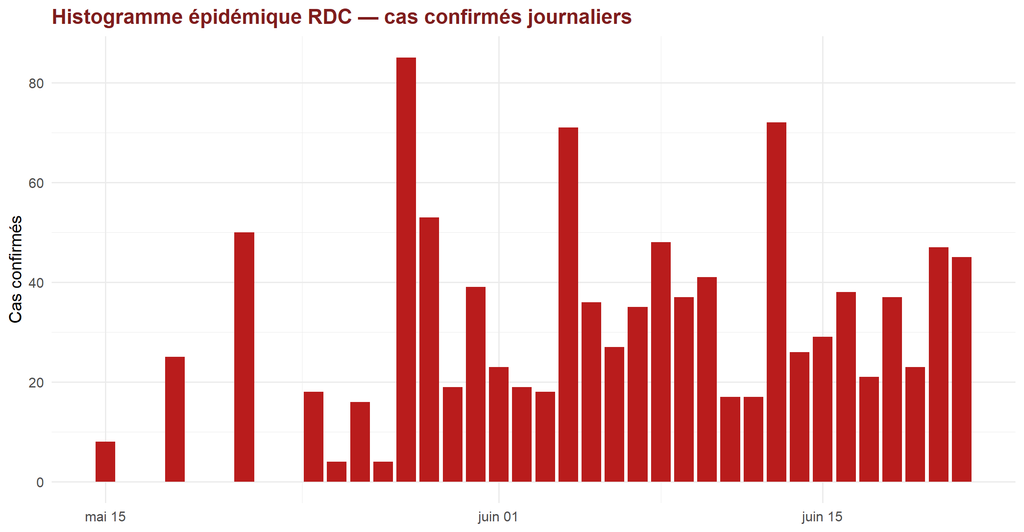

| pays | date_situation | cas_suspects | cas_confirmes | deces_confirmes | deces_probables | guerisons | cfr_confirme | source_donnees | url_source | commentaire |
| --- | --- | --- | --- | --- | --- | --- | --- | --- | --- | --- |
| RDC | 2026-06-21 | 202 | 1048 | 267 | NA | 112 | 0.25 | OMS — Daily epidemiological update, image publiée le 23 juin 2026, données au 21 juin 2026 | https://www.who.int/emergencies/alert-and-response | Valeurs de référence provisoires ; remplacer par les fichiers nationaux actualisés si disponibles. |
| Ouganda | 2026-06-21 | NA | 20 | 2 | 1 | 14 | 0.1 | OMS — Daily epidemiological update, image publiée le 23 juin 2026, données au 21 juin 2026 | https://www.who.int/emergencies/alert-and-response | Valeurs de référence provisoires ; remplacer par les fichiers nationaux actualisés si disponibles. |

## Données, hypothèses et annexes

3 lignes PoE ont une incohérence entre voyageurs et températures.

Les valeurs RDC/Ouganda de référence proviennent de l’OMS, image publiée le 23/06/2026 avec données au 21/06/2026 ; elles doivent être remplacées par les fichiers nationaux si disponibles.

Les données PoE de température ≥ 38°C sont traitées comme signaux fébriles/alertes à vérifier, et non comme cas suspects MVE sans investigation clinique.

| table | lignes | source | type |
| --- | --- | --- | --- |
| surveillance_poe | 138 | templates_donnees_dashboard_MVE.xlsx / surveillance_poe; data_aeroport.xlsx | Données réelles importées |
| activites_par_piliers | 113 | Communication de Risque et Engagement communautaire.xlsx; Continuité des services de santé, des services sociaux essentiels et des systèmes de santé communautaires.xlsx; Coordination leadership et gou… | Données réelles importées |
| formations | 2 | templates_donnees_dashboard_MVE.xlsx | Données réelles importées |
| laboratoires | 2 | templates_donnees_dashboard_MVE.xlsx | Données réelles importées |
| rdc_daily | 38 | data_rdc.xlsx | Données réelles importées |